# Data Visualization Assignment 4

Swaroop - 17230755

19 April 2018

### Overview:

The given corpus contains 19 sub corpus and corresponding documents - the sub corpus are - aa, comwm, cship, csmh, cwx, ra, rm, rsb, rsh, sc, se, sm, src, ss, tpg, tpm, tpmi, trm. Each of these contains set of documents which with specfic ids to each document i.e aa corpus - contains documents from 1-319. Initial investigation of the document reveals that, all documents is a kind of letter, which contains From, To, subject and Organization. Hence, these can be considered as stop words and need to be removed.

The main objective of this assignment is inform reader/Data Scientist as to the topic composition in the corpus.

### Approach:

First exploring the corpus - corpus statistics.

Cleaning the corpus - removal of stop words.

Tried with k-means clustering technique.

Selecting the k in k-means using elbow method.

Tried with hierarchical clustering.

Selecting the optimal height or clusters in hierarchical clustering.

Visualising the words in each clusters - word corpus.

Few more visualisations.

Importing all necessary libraries.

```r
# Importing all necessary libraries.
library(tm)
library(SnowballC)
library(wordcloud)
library(ggplot2)
library(ggdendro)
library(dplyr)
library(cluster)
library(HSAUR)
library(fpc)
library(skmeans)
library(plyr)
library(ggplot2)
library(gplots)
library(stats)
library(philentropy)
library(networkD3)
library(ape)
library(RColorBrewer)
library(wesanderson)
library(wordcloud2)
library(treemapify)
```

### Data Pre Preocessing:

This includes - removing stop words, converting all words to lowercase, removing punctuations, removing special characters and stemming. In addition, I included subject, lines, from, To, can, will, get, use as stop words because every document contains the words like subject, to and from (No differentiating power) which is removed while plotting word cloud.

```r
n <- 19
qual_col_pals = brewer.pal.info[brewer.pal.info$category == 'qual',]
col_vector = unlist(mapply(brewer.pal, qual_col_pals$maxcolors, rownames(qual_col_pals)))


corpus1 <- VCorpus(DirSource("corpus_n_topics3", recursive = TRUE, encoding = "UTF-8"),
                  readerControl = list(language = "eng"))

# Cleaning the corpus..
toSpace <- content_transformer(function (x , pattern ) gsub(pattern, " ", x))
corpus1 <- tm_map(corpus1, toSpace, "/")
corpus1 <- tm_map(corpus1, toSpace, "/.")
corpus1 <- tm_map(corpus1, toSpace, "@")
corpus1 <- tm_map(corpus1, toSpace, "\\|")

# Converting all text to lower case. removing stop words and punctuations
corpus1 <- tm_map(corpus1, content_transformer(tolower))
corpus1 <- tm_map(corpus1, removeWords, stopwords("english"))
corpus1 <- tm_map(corpus1, removePunctuation)

# Remove numbers, letters and stemming
corpus1 <- tm_map(corpus1, removeNumbers)
corpus1 <- tm_map(corpus1, removeWords, c(letters))
corpus1 <- tm_map(corpus1, stemDocument)

# Document Term Matrix and sparsity
corpus1.dtm <- DocumentTermMatrix(corpus1, control = list(weighting = function(x)
  weightTfIdf(x, normalize = TRUE)))
corpus1.dtm<-removeSparseTerms(corpus1.dtm, 0.999)
corpus1.dtm.mat <- corpus1.dtm %>% as.matrix()
corpus1.dtm.mat <- corpus1.dtm.mat[rowSums(corpus1.dtm.mat^2) !=0,]


# Taking sample from corpus:
percent = 35
set.seed(300)
sample_size = nrow(corpus1.dtm.mat) * percent/100
corpus1.dtm.mat.sample <- corpus1.dtm.mat[sample(1:nrow(corpus1.dtm.mat),
                                                sample_size, replace=FALSE),]
```

### Exploring Corpus and K means clustering:

At this stage, intially applied k mean clustering for k=3 and the dataframe obtained from this becomes easy to plot corpus statistics. Moreover, we need to find the value for K, this can be obtained from elbow method - i.e clear elbow sign, where there is drastic decrease in group sum of square distance error and after that the decrease in distance becomes almost constant. However, for given data set it is observed that there is no clear decrease in squared distance for 20 clusters. Moreover, as we increase the number of clusters, no of words in the cluster also decreases. - hence different types of clusting technique need to be implemented.

In addition, we need to group the documents into sub corpus which is done by taking document id. eg: document 1 to 319 belong to sub corpus “aa”. Similarly for others. This helps in indentifying how many documents pressent in each sub corpus.

Trying to find best K in k means clustering (Unsupervised Learning): Inference: From the below plot we can infer that no clear sign of elbow to select value of k till 20 clusters (and squared distance is still decreasing after that, this process consumes lot of time to run).

#### Elbow Method k-means:

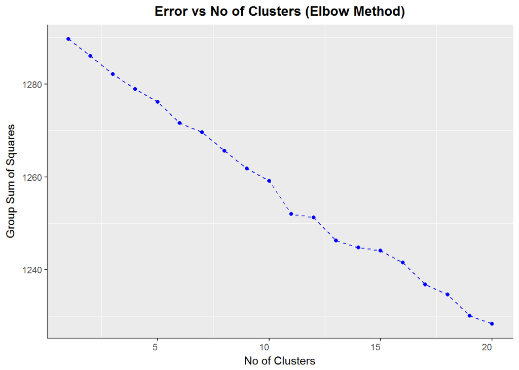

```r
# Finding Number of clusters to be selected:
wss <- 0
for (i in 1:20){
  km.out <- kmeans(corpus1.dtm.mat.sample, i)
  wss[i] <- km.out$tot.withinss
}


ggplot()+geom_point(aes(x=1:20, y=wss), colour="blue")+
  geom_line(aes(x=1:20, y=wss),linetype="dashed", colour="blue")+
  ggtitle("Error vs No of Clusters (Elbow Method)")+xlab("No of Clusters")+
  ylab("Group Sum of Squares")+
  theme(panel.grid.major = element_blank(),
        #panel.background = element_blank(),
        axis.line = element_line(colour = "black", size = 0.25),
        axis.text.x = element_text(hjust=1, vjust = .5),
        legend.key = element_rect(fill = NA, colour = NA, size = 0.25),
        plot.title = element_text(hjust = 0.5, face = "bold"),
        legend.title=element_text(size=10, face = "bold"))
```

```r
#plot(1:10, wss, type = "b",
     #xlab = "Number of Clusters",
     #ylab = "Within groups sum of squares")


corpus1.dtm.mat.sample.skm <- skmeans(corpus1.dtm.mat.sample,3, method='genetic')

corpus1.dtm.mat.sample.skm <- as.data.frame(corpus1.dtm.mat.sample.skm$cluster)
colnames(corpus1.dtm.mat.sample.skm) = c("cluster")
corpus1.dtm.mat.sample.skm$docs <- rownames(corpus1.dtm.mat.sample.skm)

corpus1.dtm.mat.sample.skm$docs<-lapply(corpus1.dtm.mat.sample.skm$docs, function(x) gsub("doc", "", x))
corpus1.dtm.mat.sample.skm$docs <- unlist(corpus1.dtm.mat.sample.skm$docs)

# Not necessry - k means consumes lot of time hence as a backup.
x = corpus1.dtm.mat.sample.skm$docs
corpus1.dtm.mat.sample.skm$docs <- as.numeric(x)


library(dplyr)
corpus1.dtm.mat.sample.skm <- corpus1.dtm.mat.sample.skm %>%
  mutate(doc = case_when(
    .$docs >= 1 & .$docs <= 319 ~ "aa",
    .$docs >= 320 & .$docs <= 708 ~ "cg",
    .$docs >= 709 & .$docs <= 1102 ~ "comwm",
    .$docs >= 1103 & .$docs <= 1494 ~ "cship",
    .$docs >= 1495 & .$docs <= 1879 ~ "csmh",
    .$docs >= 1880 & .$docs <= 2274 ~ "cwx",
    .$docs >= 2275 & .$docs <= 2670 ~ "ra",
    .$docs >= 2671 & .$docs <= 3068 ~ "rm",
    .$docs >= 3069 & .$docs <= 3465 ~ "rsb",
    .$docs >= 3466 & .$docs <= 3864 ~ "rsh",
    .$docs >= 3865 & .$docs <= 4260 ~ "sc",
    .$docs >= 4261 & .$docs <= 4653 ~ "se",
    .$docs >= 4654 & .$docs <= 5049 ~ "sm",
    .$docs >= 5050 & .$docs <= 5447 ~ "src",
    .$docs >= 5448 & .$docs <= 5841 ~ "ss",
    .$docs >= 5842 & .$docs <= 6205 ~ "tpg",
    .$docs >= 6206 & .$docs <= 6581 ~ "tpm",
    .$docs >= 6582 & .$docs <= 6891 ~ "tpmi",
    .$docs >= 6892 & .$docs <= 7142 ~ "trm"
)
)

corpus1.dtm.mat.sample.skm <- corpus1.dtm.mat.sample.skm[, -2]



corpus1.dtm.mat.sample.skm.table <-table(corpus1.dtm.mat.sample.skm$cluster, corpus1.dtm.mat.sample.skm$doc)


corpus1.dtm.mat.sample.skm.table <-as.data.frame.table(corpus1.dtm.mat.sample.skm.table)
```